# esm204assignment4

Cristina Mancilla, Kat Orellana, Ridhima Chaudhuri

5/23/2022

```r
knitr::opts_chunk$set(echo = TRUE, message = FALSE, warning = FALSE)

library(tidyverse)
library(rootSolve)
library(janitor)
library(tibble)
library(here)
```

#### 1. Using damages.csv, estimate a quadratic damage function relating the dollar value of damages to the change in global mean temperature. Estimate a model with a zero intercept because damages by construction must equal zero when there is no climate change. Plot your estimated damage function, overlaid with a scatterplot of the underlying data.

```r
warming <- read_csv(here("data", "warming.csv"))

damages <- read_csv(here("data", "damages.csv"))
```

```r
damages <- damages %>%
mutate(damages, warming_2 = warming^2)
```

```r
model_damages_quadratic <- lm(damages ~ 0 + warming + warming_2, data = damages)
summary(model_damages_quadratic)
```

```
##
## Call:
## lm(formula = damages ~ 0 + warming + warming_2, data = damages)
##
## Residuals:
##        Min         1Q     Median         3Q        Max
## -1.384e+14 -1.637e+13  8.574e+11  1.752e+13  1.416e+14
##
## Coefficients:
##             Estimate Std. Error t value Pr(>|t|)
## warming   -1.060e+12  9.625e+11  -1.101    0.271
## warming_2  1.941e+13  1.585e+11 122.431   <2e-16 ***
## ---
## Signif. codes:  0 '***' 0.001 '**' 0.01 '*' 0.05 '.' 0.1 ' ' 1
##
## Residual standard error: 3.466e+13 on 554 degrees of freedom
## Multiple R-squared:  0.994,  Adjusted R-squared:  0.9939
## F-statistic: 4.563e+04 on 2 and 554 DF,  p-value: < 2.2e-16
```

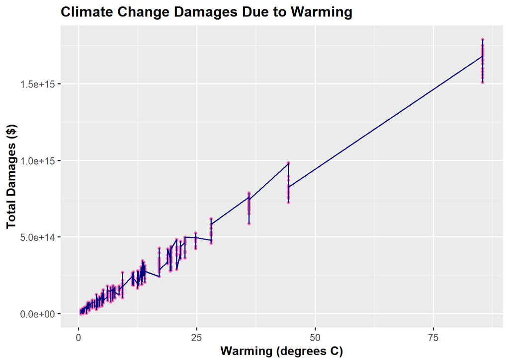

```r
ggplot(damages,aes(x=warming_2, y=damages)) +
  geom_point( size=1.2, color = "hotpink1") +
  geom_line(size = 0.6, data = damages, aes(x=warming_2, y=damages), color = "navyblue") +
  labs(x = "Warming (degrees C)", y = "Total Damages ($)", title = "Climate Change Damages Due to Warming") +
  theme(strip.background = element_rect(color= "white", fill = "gray"))+
  theme_grey(12) +
  theme(plot.title = element_text(face = "bold")) +
  theme(axis.title = element_text(face = "bold"))
```

#### 2.Use warming.csv and your estimated damage function to predict damages in each year under the baseline climate and the pulse scenario. Make four plots: (1) damages over time without the pulse, (2) damages over time with the pulse, (3) the difference in damages over time that arises from the pulse, and (4) the difference in damages over time from the pulse per ton of CO2 (you can assume that each ton of the pulse causes the same amount of damage).

```r
damages_function <- function(warming){
  damages <- model_damages_quadratic$coefficient[1] * warming + model_damages_quadratic$coefficient[2] * (warming^2)
  return(damages)
}
```

```r
warming <- warming %>%
  mutate(damages_baseline = damages_function(warming_baseline)) %>%
  mutate(damages_pulse = damages_function(warming_pulse))%>%
  mutate(damages_difference = damages_function(warming_pulse) - damages_function(warming_baseline))%>%
  mutate(damages_difference_ton = (damages_function(warming_pulse) - damages_function(warming_baseline)) / 35000000000)
```

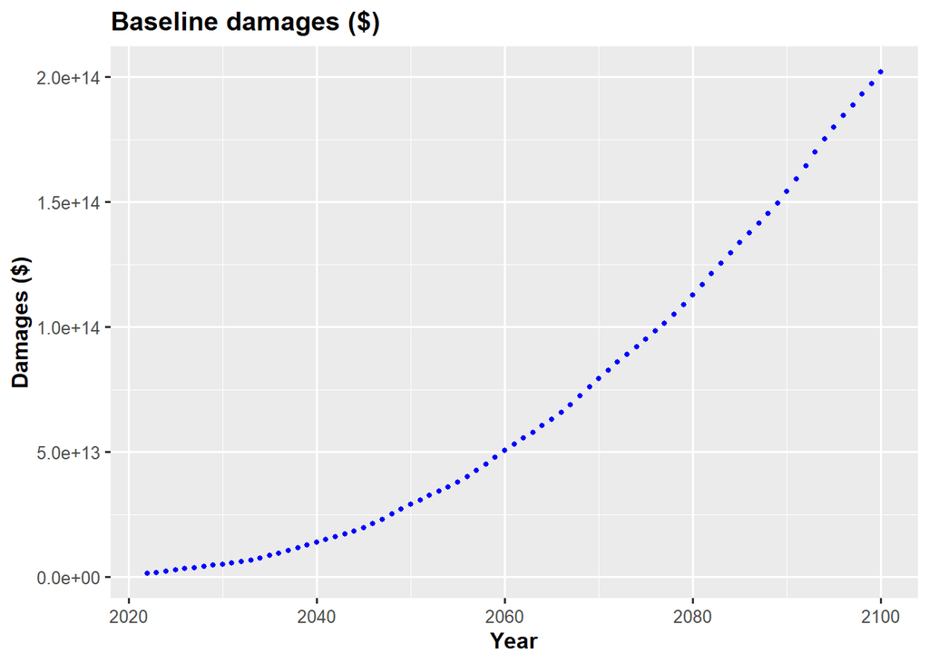

```r
ggplot(warming, aes(x = year, y = damages_baseline)) +
  geom_point(size = 1, color= "blue") +
  labs(x = "Year", y = "Damages ($)", title = "Baseline damages ($)") +
  theme_grey(12) +
  theme(plot.title = element_text(face = "bold")) +
  theme(axis.title = element_text(face = "bold"))
```

**Figure 1:** The plot shows the damages (in dollars) per year under baseline climate.

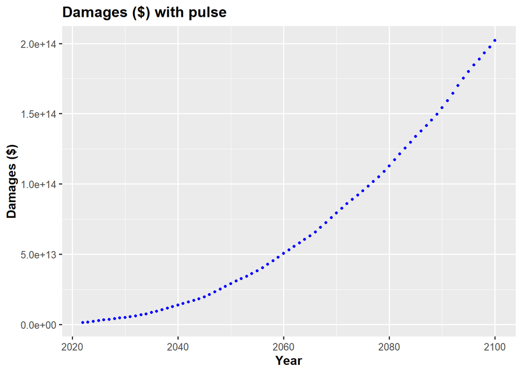

```r
ggplot(warming, aes(x = year, y = damages_pulse)) +
  geom_point(size = 1, color= "blue") +
  labs(x = "Year", y = "Damages ($)", title = "Damages ($) with pulse") +
  theme_grey(12) +
  theme(plot.title = element_text(face = "bold")) +
  theme(axis.title = element_text(face = "bold"))
```

**Figure 2:** The plot shows damages (in dollars) per year with a 35 billion ton carbon pulse scenario.

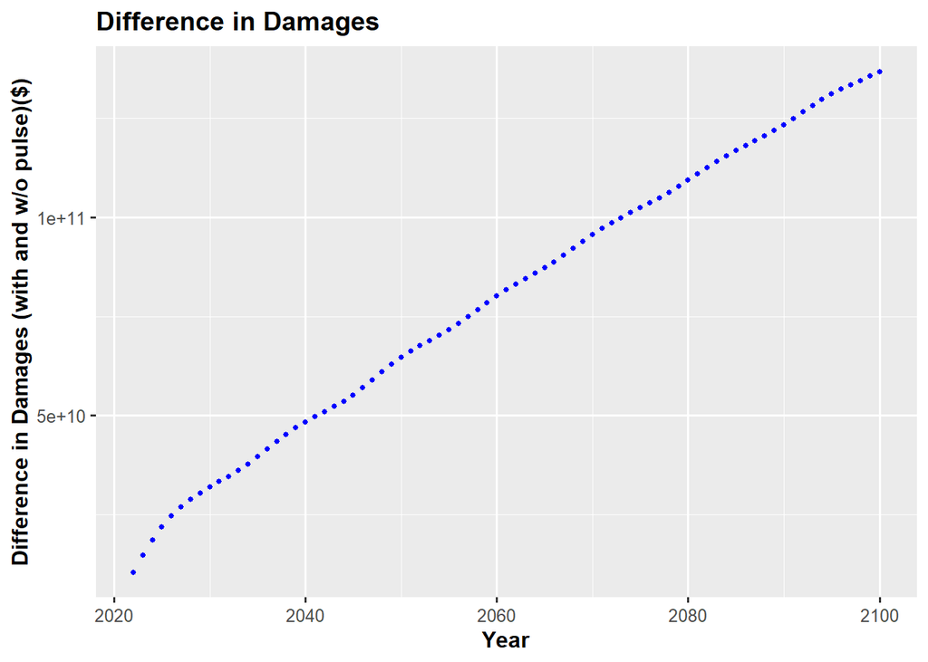

```r
ggplot(warming, aes(x = year, y = damages_difference)) +
  geom_point(size = 1, color="blue") +
  labs(x = "Year", y = "Difference in Damages (with and w/o pulse)($)", title = "Difference in Damages") +
  theme_grey(12) +
  theme(plot.title = element_text(face = "bold")) +
  theme(axis.title = element_text(face = "bold"))
```

**Figure 3:** The plot shows the difference in damages (dollars) over time from the pulse scenario

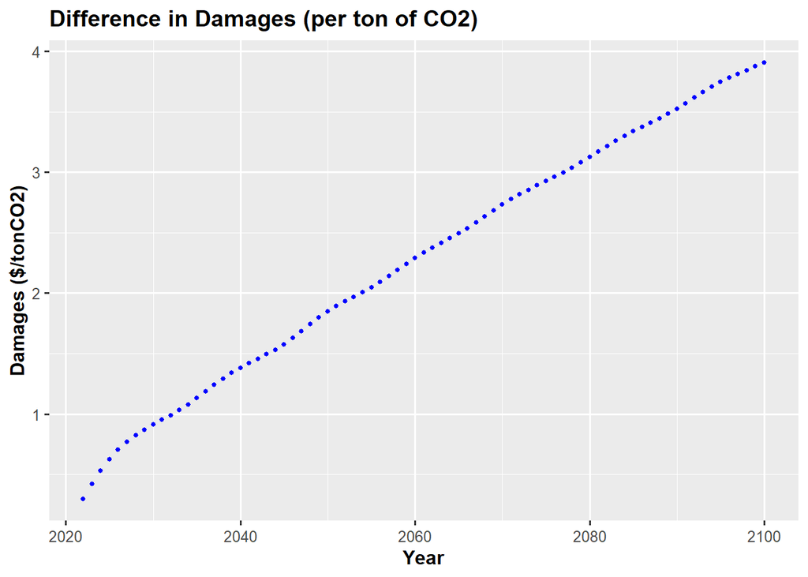

```r
ggplot(warming, aes(x = year, y = damages_difference_ton )) +
  geom_point(size = 1, color="blue") +
  labs(x = "Year", y = "Damages ($/tonCO2)", title = "Difference in Damages (per ton of CO2)") +
  theme_grey(12) +
  theme(plot.title = element_text(face = "bold")) +
  theme(axis.title = element_text(face = "bold"))
```

**Figure 4:** The plot shows the difference in damages (dollars) over time from the pulse per ton of CO2.

```r
social_cost_damages <- warming %>%
  select(year, damages_difference_ton) %>%
  mutate(value_0 = damages_difference_ton * ((1 + 0.0)^(-(year-2022)))) %>%
  mutate(value_1 = damages_difference_ton * ((1 + 0.01)^(-(year-2022)))) %>%
  mutate(value_2 = damages_difference_ton * ((1 + 0.02)^(-(year-2022)))) %>%
  mutate(value_3 = damages_difference_ton * ((1 + 0.03)^(-(year-2022)))) %>%
  mutate(value_4 = damages_difference_ton * ((1 + 0.04)^(-(year-2022)))) %>%
  mutate(value_5 = damages_difference_ton * ((1 + 0.05)^(-(year-2022)))) %>%
  mutate(value_6 = damages_difference_ton * ((1 + 0.06)^(-(year-2022))))
```

```r
## finding the discount rate

discount_rates <- c(0,1,2,3,4,5,6)
social_cost_carbon <- c(sum(social_cost_damages$value_0),
                        sum(social_cost_damages$value_1),
                        sum(social_cost_damages$value_2),
                        sum(social_cost_damages$value_3),
                        sum(social_cost_damages$value_4),
                        sum(social_cost_damages$value_5),
                        sum(social_cost_damages$value_6))

#create dataframe with the social cost of carbon sums and the discount rate

scc <- data.frame(discount_rates, social_cost_carbon)
```

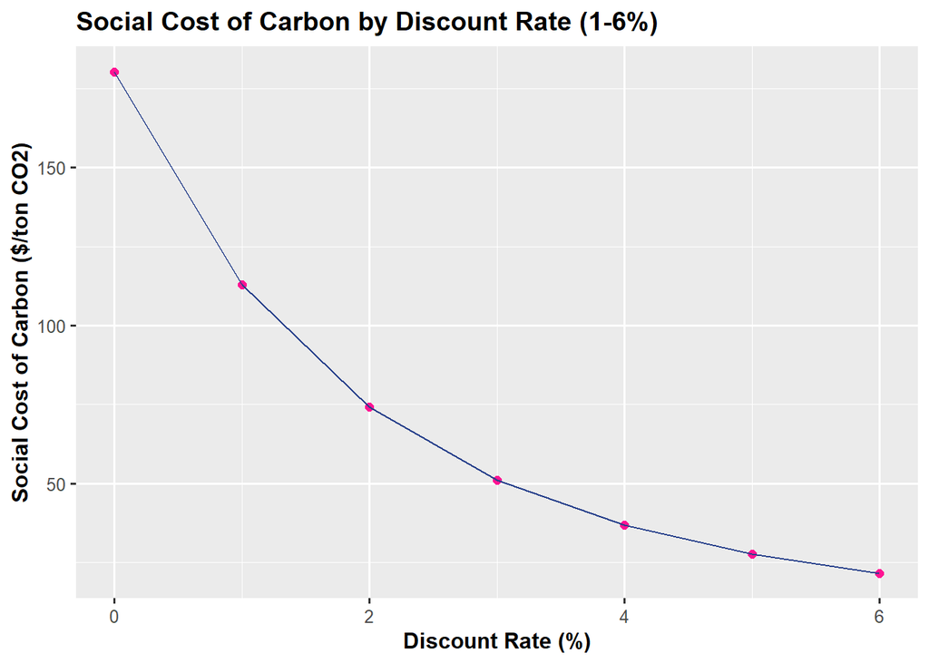

```r
# graph the social cost of carbon and the discount rates (1 - 6%)

ggplot(data = scc, aes(x = discount_rates, y = social_cost_carbon))+
  geom_point(size = 2, color = "deeppink1")+
  geom_line(color = "royalblue4")+
  labs(x= "Discount Rate (%)", y = "Social Cost of Carbon ($/ton CO2)", title = "Social Cost of Carbon by Discount Rate (1-6%)") +
  theme_grey(12)+
  theme(plot.title = element_text(face = "bold"))+
  theme(axis.title = element_text(face = "bold"))
```

**Figure 5:** The plot shows the social cost of carbon (SCC) caused by one additional unit of CO2 compared to the discount rate.

#### 4. The National Academies of Sciences, Engineering, and Medicine advised the government in a 2017 report to use the Ramsey Rule when discounting within the SCC calculation:

```
 r = ρ + ηg
```

Using ρ = 0.001, η = 2, and g = 0.01, what is the SCC? Locate this point on your graph from above.

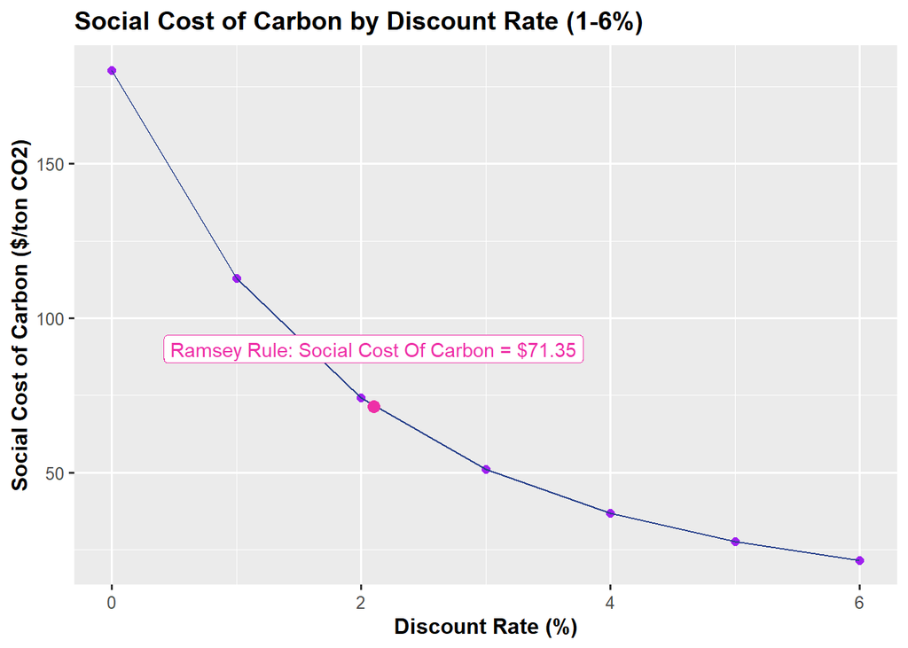

```r
ramsey <- (0.001 + (2 * 0.01)) * 100


ramsey_social_cost <- warming %>%
  select(year, damages_difference_ton) %>%
  mutate(ramsey_value = damages_difference_ton * ((1 + (ramsey/100))^(-(year-2022))))

ramsey_sum_social <- sum(ramsey_social_cost$ramsey_value)




  ggplot(data = scc, aes(x = discount_rates, y = social_cost_carbon))+
  geom_point(size = 2, color = "purple")+
  geom_line(color = "royalblue4")+
    geom_point(aes(x = ramsey, y = ramsey_sum_social), color = "maroon2", size = 3) +
    geom_label(aes(x=2.1, label= "Ramsey Rule: Social Cost Of Carbon = $71.35", y=90), color= "maroon2", angle= 90) +
  labs(x= "Discount Rate (%)", y = "Social Cost of Carbon ($/ton CO2)", title = "Social Cost of Carbon by Discount Rate (1-6%)") +
  theme_grey(12)+
  theme(plot.title = element_text(face = "bold"))+
  theme(axis.title = element_text(face = "bold"))
```

**Figure 6:** the pink dot represents the Ramsey Rate discount rate and Social Cost of Carbon calculation

#### 5. Now suppose there are two possible climate policies that can be pursued. Policy A is business as usual and Policy B is to take immediate and strong action on climate change. Use these facts:

• If you undertake Policy A there are two possible outcomes. Either warming will occur as in the “baseline” (i.e. “no-pulse”) dataset above (this happens with probability 0.5) or warming each year will be 1.5 times that in the “baseline” dataset (with probability 0.5).

Under Policy B, warming will continue until 2050 as in the “baseline” dataset, and then will stabilize at 1.29 degrees and stay that way forever. • Society is risk neutral • Use a discount rate of 2%

```r
with_policies <- warming %>%
  mutate(policy_a = 1.5 *warming_baseline) %>%
  mutate(damages_a = damages_function(policy_a)) %>%
  mutate(damages_a_discount = damages_a/(1.02^(-(year-2022)))) %>%

  mutate(policy_b = ifelse(year < 2050, warming_baseline, 1.29)) %>%
  mutate(damages_b = damages_function(policy_b)) %>%
  mutate(damages_b_discounted = damages_b/(1.02^(-(year-2022)))) %>%


  mutate(baseline_discounted = damages_baseline/(1.02^(-(year-2022))))
```

```r
expected_a <- 0.5*sum(with_policies$damages_baseline_discounted) + 0.5 * sum(with_policies$damages_a_discount)
expected_b <-sum(with_policies$damages_b_discounted)
```

```r
# creating a dataframe for cost

cost_a <- function(x){expected_a}
cost_b <- function(x){expected_b+x}

costs <- c(0,1e16, 2e16, 3e16, 4e16, 5e16, 6e16)
total_cost_a <- c(NA, NA, NA, NA, NA, NA, NA)
total_cost_b <- c(NA, NA, NA, NA, NA, NA, NA)

cost_df <- data.frame(costs, total_cost_a, total_cost_b)

# fill in the empty columns in the dataframe

cost_df <- cost_df %>%
mutate(total_cost_a = expected_a)%>%
mutate(total_cost_b = expected_b + costs)
```

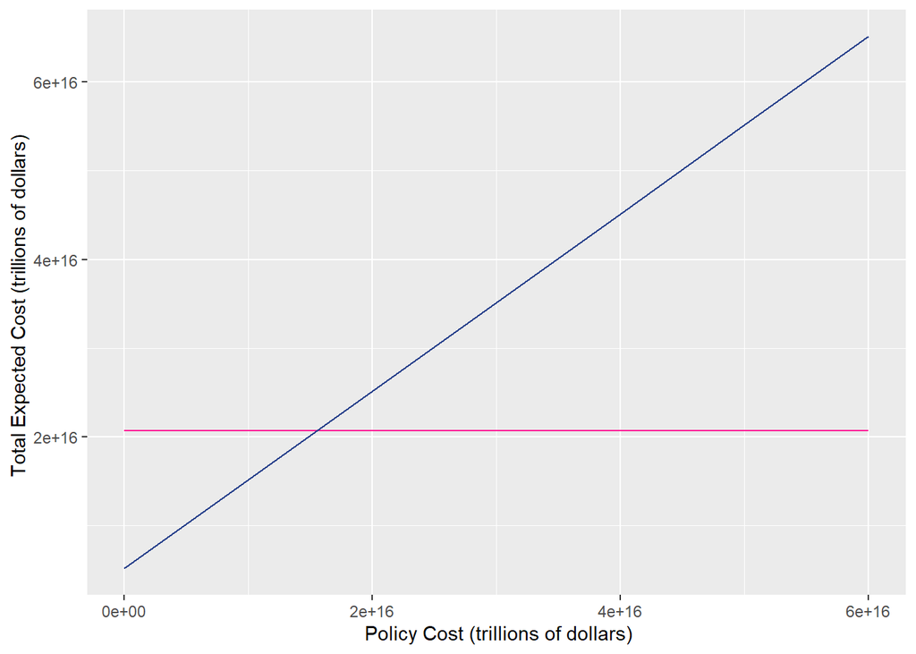

```r
ggplot(data = cost_df) +
  geom_line(aes(x=costs, y = total_cost_a), color = "deeppink1")+
  geom_line(aes(x=costs, y = total_cost_b), color = "royalblue4")+
  labs(x = " Policy Cost (trillions of dollars)", y = "Total Expected Cost (trillions of dollars) ")
```